# Statistics and Applications Project

Ahmadreza Tavana

1/29/2022

# Libraries

In this section, at first we include libraries that we need in our project.

##### IMPORTANT NOTE: IF YOU NEED TO INSTALL PACKAGE OF ANY OF BELOW LIBRARIES, PLEASE INSTALL IT. THANKS

```r
library(ggplot2)
library(fastR2)
library(dplyr)
library(readr)
library(tidyr)
library(stringr)
library(MASS)
library(readxl)
library(writexl)
```

# Question 1

## 1.a

### 1.a.i

In this part I decide to plot Gamma distribution with rate 2

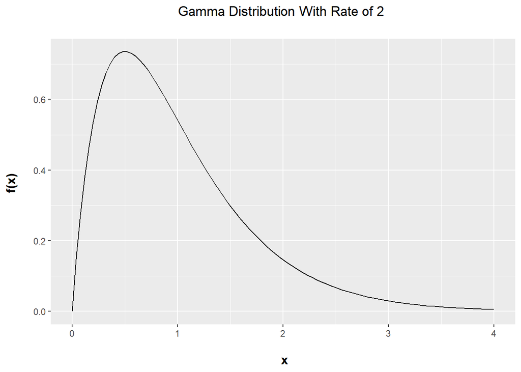

```r
##### Question 1 part a.i
# Gamma Distribution Plot With Rate = 2

ggplot(data.frame(x = c(0 , 4)), aes(x = x)) +
  xlim(c(0 , 4)) +
  stat_function(fun = dgamma, args = list(rate = 2, shape = 2)) +
  labs(x = "\n x", y = "f(x) \n",
       title = "Gamma Distribution With Rate of 2 \n") +
  theme(plot.title = element_text(hjust = 0.5),
        axis.title.x = element_text(face="bold", size = 12),
        axis.title.y = element_text(face="bold", size = 12))
```

### 1.a.ii

In this part we have to pick up 10,100 and 1000 sample with 50 member from our Gamma distribution.

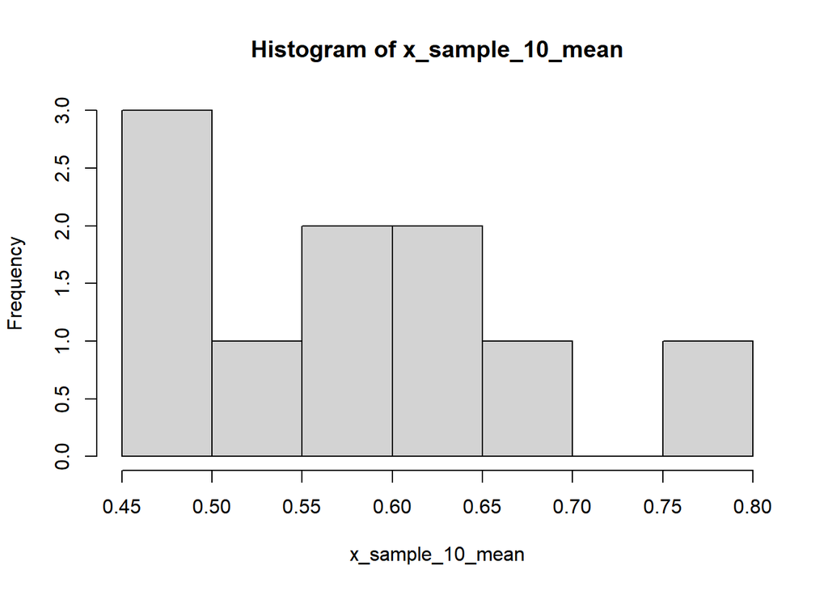

```r
#### picking up 10 sample of 50 member from our gamma distribution

x_sample_10 <- matrix(1,nrow = 50, ncol = 10)

for(i in 1:10){
  x_sample_10[1:50,i] <- rgamma(50,0.5)  ### we have to put 0.5 as second input of rgamma for rate of 2
}

x_sample_10_mean <- c(1:10)
for (i in 1:10){
  x_sample_10_mean[i] = mean(x_sample_10[1:50,i])
}
hist(x_sample_10_mean)
```

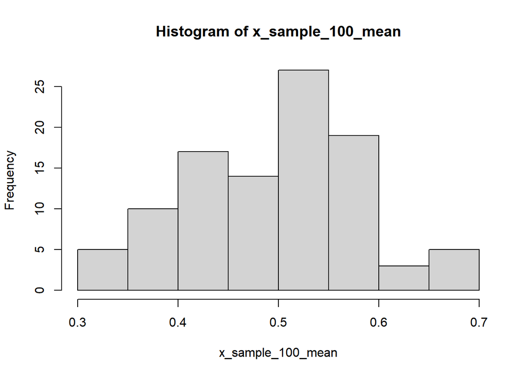

```r
#### picking up 100 sample of 50 member from our gamma distribution

x_sample_100 <- matrix(1,nrow = 50, ncol = 100)

for(i in 1:100){
  x_sample_100[1:50,i] <- rgamma(50,0.5)
}

x_sample_100_mean <- c(1:100)
for (i in 1:100){
  x_sample_100_mean[i] = mean(x_sample_100[1:50,i])
}
hist(x_sample_100_mean)
```

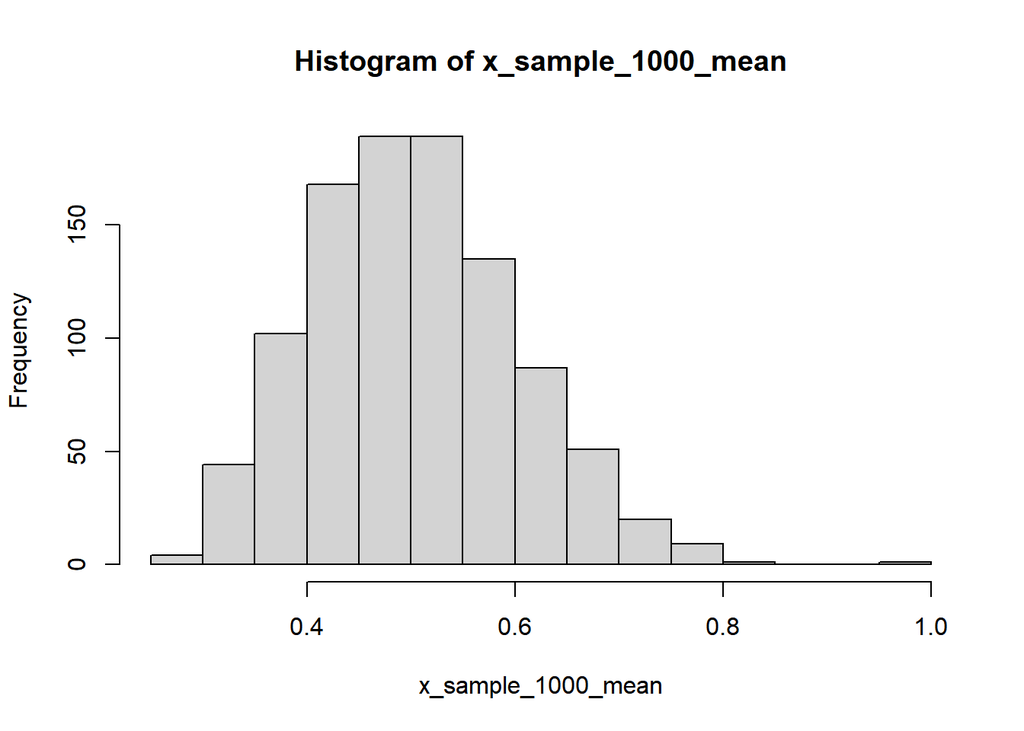

```r
#### picking up 1000 sample of 50 member from our gamma distribution

x_sample_1000 <- matrix(1,nrow = 50, ncol = 1000)

for(i in 1:1000){
  x_sample_1000[1:50,i] <- rgamma(50,0.5)
}

x_sample_1000_mean <- c(1:1000)
for (i in 1:1000){
  x_sample_1000_mean[i] = mean(x_sample_1000[1:50,i])
}
hist(x_sample_1000_mean)
```

### 1.a.iii

In this part we have to check CLT theorem in our data.

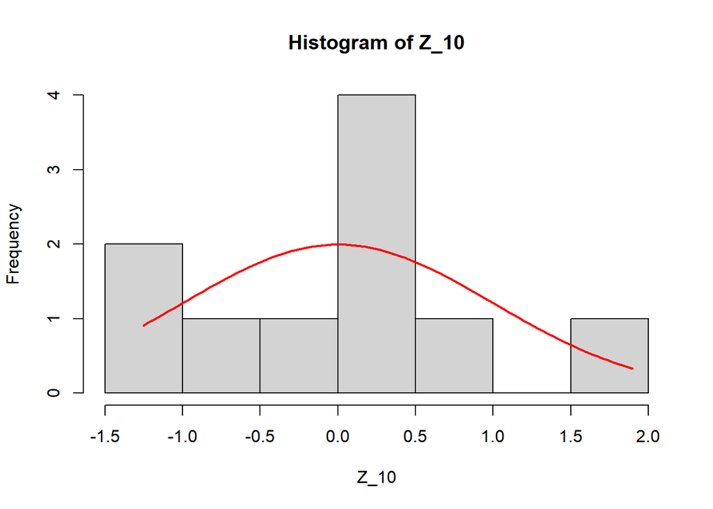

```r
### Z value for 10 sample

mean_of_10_sample = mean(x_sample_10_mean)
var_of_10_sample = var(x_sample_10_mean)

Z_10 = (x_sample_10_mean - mean_of_10_sample) / (sqrt(var_of_10_sample))

his_10 = hist(Z_10)

# overlay normal distribution to our histogram
xfit<-seq(min(Z_10),max(Z_10),length = 100)
yfit<-dnorm(xfit,mean=mean(Z_10),sd=sd(Z_10))
yfit <- yfit*diff(his_10$mids[1:2])*length(Z_10)

lines(xfit, yfit, col="red", lwd=2)
```

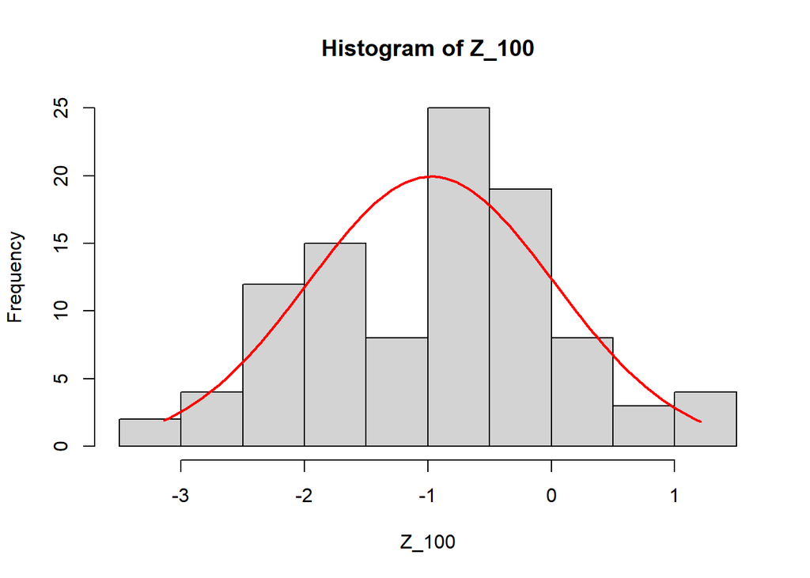

```r
### Z value for 100 sample

mean_of_100_sample = mean(x_sample_100_mean)
var_of_100_sample = var(x_sample_100_mean)

Z_100 = (x_sample_100_mean - mean_of_10_sample) / (sqrt(var_of_100_sample))

his_100 = hist(Z_100)

# overlay normal distribution to our histogram
xfit<-seq(min(Z_100),max(Z_100),length = 100)
yfit<-dnorm(xfit,mean=mean(Z_100),sd=sd(Z_100))
yfit <- yfit*diff(his_100$mids[1:2])*length(Z_100)

lines(xfit, yfit, col="red", lwd=2)
```

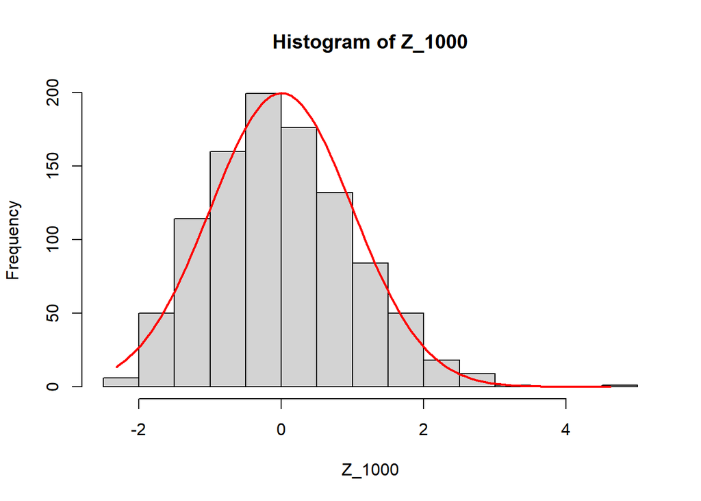

```r
### Z value for 1000 sample

mean_of_1000_sample = mean(x_sample_1000_mean)
var_of_1000_sample = var(x_sample_1000_mean)

Z_1000 = (x_sample_1000_mean - mean_of_1000_sample) / (sqrt(var_of_1000_sample))

his_1000 = hist(Z_1000)

# overlay normal distribution to our histogram
xfit<-seq(min(Z_1000),max(Z_1000),length = 100)
yfit<-dnorm(xfit,mean=mean(Z_1000),sd=sd(Z_1000))
yfit <- yfit*diff(his_1000$mids[1:2])*length(Z_1000)

lines(xfit, yfit, col="red", lwd=2)
```

As we can see, as the size of our sample increases, the histogram of our sample tends to standard normal distribution.

## 1.b

In this part we work with “Birth” data from “fastR2” library

### 1.b.i

```r
#### loading data
data("Births")
## Figuring out the day that has the minimum mean of birth in 20 years

days_mean = c(1:366)

for (i in 1:366){
  days_mean[i] = mean(Births$births[Births$day_of_year == i])
}
cat("The minumum mean of birth of a day in all these 20 years is:\n",min(days_mean))
```

```
## The minumum mean of birth of a day in all these 20 years is:
##  7688.9
```

```r
for (i in 1:366){
  if(days_mean[i] == min(days_mean)){
    min_day_birth = i
  }
}
cat("The day that has the minimum mean of of birth in all these 20 years is:\n",min_day_birth,"th day of year")
```

```
## The day that has the minimum mean of of birth in all these 20 years is:
##  360 th day of year
```

```r
## Figuring out the day that has the minimum mean of birth in 20 years

cat("The maximum mean of birth of a day in all these 20 years is: \n",max(days_mean))
```

```
## The maximum mean of birth of a day in all these 20 years is:
##  10645.75
```

```r
for (i in 1:366){
  if(days_mean[i] == max(days_mean)){
    max_day_birth = i
  }
}
cat("The day that has the maximum mean of of birth in all these 20 years is:\n",max_day_birth,"th day of year")
```

```
## The day that has the maximum mean of of birth in all these 20 years is:
##  260 th day of year
```

### 1.b.ii

```r
### sorting month base on their mean of birth in 20 years

months_mean = c(1:12)

for (i in 1:12){
  months_mean[i] = sum(Births$births[Births$month == i])/20
}


df_month_mean = data.frame(month_name = c("Jan","Feb","Mar","Apr","May","Jun","July","Aug","Sep","Oct","Nov","Dec"),months_mean)

### Data frame of births mean of months
df_month_mean
```

```
##    month_name months_mean
## 1         Jan    287958.2
## 2         Feb    268129.2
## 3         Mar    293407.0
## 4         Apr    278038.8
## 5         May    289261.0
## 6         Jun    287928.5
## 7        July    311014.8
## 8         Aug    315488.2
## 9         Sep    310298.6
## 10        Oct    302768.6
## 11        Nov    284763.7
## 12        Dec    295218.8
```

```r
### Data frame of births mean of months sortet by max to min
df_month_mean[order(df_month_mean$months_mean,decreasing = 1),]
```

```
##    month_name months_mean
## 8         Aug    315488.2
## 7        July    311014.8
## 9         Sep    310298.6
## 10        Oct    302768.6
## 12        Dec    295218.8
## 3         Mar    293407.0
## 5         May    289261.0
## 1         Jan    287958.2
## 6         Jun    287928.5
## 11        Nov    284763.7
## 4         Apr    278038.8
## 2         Feb    268129.2
```

### 1.b.iii

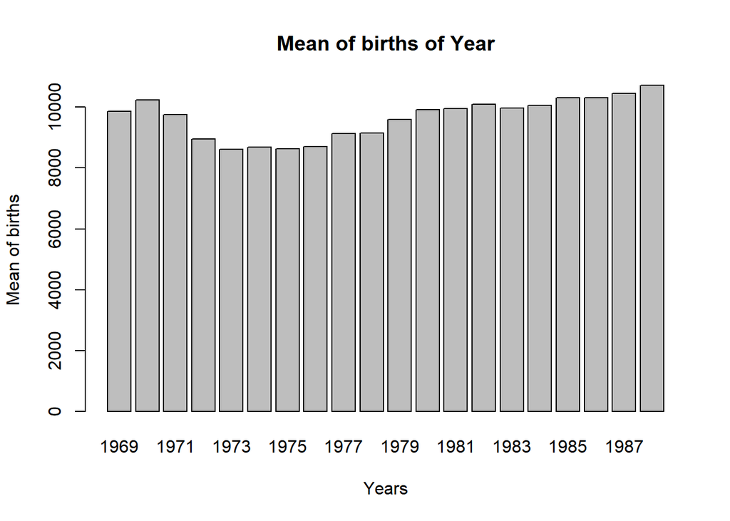

```r
years_mean = c(1:20)

for (i in 1:20){
  years_mean[i] = sum(Births$births[Births$year == i+1968])/365
}

barplot(years_mean,main = "Mean of births of Year",xlab = "Years", ylab = "Mean of births",names.arg = c(1969:1988))
```

## 1.c

```r
#### Sorting data base on date of happening
storms_report = storms[order(storms$year,storms$month,storms$day,storms$hour),]
storms_report
```

```
## # A tibble: 10,010 x 13
##    name   year month   day  hour   lat  long status      category  wind pressure
##    <chr> <dbl> <dbl> <int> <dbl> <dbl> <dbl> <chr>       <ord>    <int>    <int>
##  1 Amy    1975     6    27     0  27.5 -79   tropical d~ -1          25     1013
##  2 Amy    1975     6    27     6  28.5 -79   tropical d~ -1          25     1013
##  3 Amy    1975     6    27    12  29.5 -79   tropical d~ -1          25     1013
##  4 Amy    1975     6    27    18  30.5 -79   tropical d~ -1          25     1013
##  5 Amy    1975     6    28     0  31.5 -78.8 tropical d~ -1          25     1012
##  6 Amy    1975     6    28     6  32.4 -78.7 tropical d~ -1          25     1012
##  7 Amy    1975     6    28    12  33.3 -78   tropical d~ -1          25     1011
##  8 Amy    1975     6    28    18  34   -77   tropical d~ -1          30     1006
##  9 Amy    1975     6    29     0  34.4 -75.8 tropical s~ 0           35     1004
## 10 Amy    1975     6    29     6  34   -74.8 tropical s~ 0           40     1002
## # ... with 10,000 more rows, and 2 more variables: ts_diameter <dbl>,
## #   hu_diameter <dbl>
```

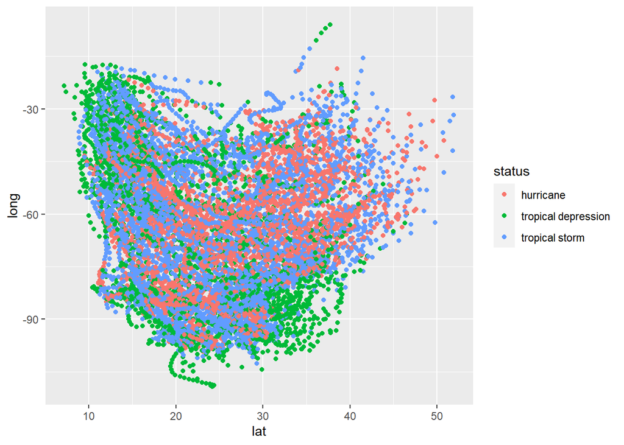

```r
#### Saving storms_report data frame as a csv file
write.csv(storms_report, file = "storms_report.csv")

#### Plotting storms coordinates
lat = storms$lat
long = storms$long
status = storms$status

ggplot(data = storms) + geom_point(mapping = aes(x = lat,y = long, color = status))
```

# Question 2

## 2.a

### 2.a.i

```r
#### At first we load had.txt file and then seprate the last part from the other parts
hadFile <- read.delim("had.txt",header = FALSE)
colnames(hadFile) <- c("Age", "Sex", "ChestPain", "BP", "Cholesterol", "BS", "Lable")

lable = data.frame(Lable = hadFile[,c(7)],lable_num = c(1:303))
## we added features_num to manage row numbers to organize data for the next part

features = data.frame(hadFile[,c(1:6)],features_num = c(1:303))
## we added lable_num to manage row numbers to organize data for next part
```

### 2.a.ii

```r
sample_train = sample(nrow(features), size=240)
features_train = features[sample_train, ]
lable_train = lable[sample_train, ]

features_test = features[-features_train$features_num,]
lable_test = lable[-lable_train$lable_num,]

#### Saving data frames as txt file

write.table(features_train,"features_train.txt",sep="\t")
write.table(lable_train,"lable_train.txt",sep="\t")
write.table(features_test,"features_test.txt",sep="\t")
write.table(lable_test,"lable_test.txt",sep="\t")
```

## 2.b

### 2.b.i

```r
Lable = lable_train$Lable
Age = features_train$Age
Sex = features_train$Sex
ChestPain = features_train$ChestPain
BP = features_train$BP
Cholesterol = features_train$Cholesterol
BS = features_train$BS

features_train$ChestPain = as.factor(features_train$ChestPain)


train_regression = lm(Lable ~ Age + Sex + ChestPain + BP + Cholesterol + BS)

summary(train_regression)
```

```
##
## Call:
## lm(formula = Lable ~ Age + Sex + ChestPain + BP + Cholesterol +
##     BS)
##
## Residuals:
##      Min       1Q   Median       3Q      Max
## -2.01136 -0.61282 -0.05134  0.71667  1.82428
##
## Coefficients:
##               Estimate Std. Error t value Pr(>|t|)
## (Intercept)  2.0645163  0.5341241   3.865 0.000144 ***
## Age         -0.0180749  0.0066934  -2.700 0.007434 **
## Sex         -0.6178026  0.1218884  -5.069 8.16e-07 ***
## ChestPain    0.3645074  0.0543364   6.708 1.48e-10 ***
## BP          -0.0059424  0.0033984  -1.749 0.081685 .
## Cholesterol -0.0005582  0.0011236  -0.497 0.619790
## BS          -0.1126416  0.1637335  -0.688 0.492164
## ---
## Signif. codes:  0 '***' 0.001 '**' 0.01 '*' 0.05 '.' 0.1 ' ' 1
##
## Residual standard error: 0.8557 on 233 degrees of freedom
## Multiple R-squared:  0.2842, Adjusted R-squared:  0.2657
## F-statistic: 15.42 on 6 and 233 DF,  p-value: 7.134e-15
```

summary function show Residuals min, 1Q, Median, 3Q, Max that shows the bar chart of our regression. For coefficients that we obtain from our regression, we have a estimation of coefficients and standard error of them and then it has a T test that calculates the t value for that and then calculate the probability of that t value. After coefficients parameters it calculates Residual standard error with degree of freedom of that dataset. Then it calculates R-squared value and do F test and calculate the F-value with degree of freedom of data set. At the end it calculates the p-value of estimated regression for figuring out the validation of our regression.

### 2.b.ii

One way to make parameter more comparable is that we normalize coefficients in the way that coefficients be near each other. For example for sex, we have 0 or 1 so for age we can separate ages and assign numbers from 0 to 3 to them, for example 0 for 0 to 25, 1 for 25 to 50 and 2 for 50 to 75 and 3 for 75 to 100 and so on. And we can do this for other parameters that have bigger value than others so we can regress them with same scale and decrease the error of our conclusion.

## 2.c

### 2.c.i

```r
##### testing regression to feature test and checking the amount with limit = 0

features_check = c(1:63)

### calculating the amount of regression to compare the sign with lim = 0
for (i in 1:63){
  features_check[i] = train_regression$coefficients[1] + sum(matrix(train_regression$coefficients[2:7]) * as.numeric(matrix(features_test[i,1:6])))
}

final_checking_features = ifelse(features_check>=0,1,-1) ## comparing with lim = 0

lable_test_T_F = lable_test$Lable == 1
final_checking_features_T_F = final_checking_features == 1

### comparing test features and checking features by regression with lim = 0

final_T_F = lable_test_T_F == final_checking_features_T_F

sum_of_T = sum(final_T_F, na.rm = TRUE)

accuracy_lable = sum(final_T_F, na.rm = TRUE)/63

accuracy_lable
```

```
## [1] 0.8253968
```

### 2.c.ii

```r
lim_size = seq(-2,2,length = 10000)

accuracy_lim_lable = c(1:10000)

for(i in 1:10000){
  final_checking_features = ifelse(features_check>=lim_size[i],1,-1)

  lable_test_T_F = lable_test$Lable == 1
  final_checking_features_T_F = final_checking_features == 1


  final_T_F = lable_test_T_F == final_checking_features_T_F

  sum_of_T = sum(final_T_F, na.rm = TRUE)

  accuracy_lim_lable[i] = sum(final_T_F, na.rm = TRUE)/63

}

### finding the best lim that gives us the best accuracy
max_lim = max(accuracy_lim_lable)
best_lim = match(max_lim,accuracy_lim_lable)
### maximum accuracy that we can have
max_lim
```

```
## [1] 0.8571429
```

```r
### best amount of lim for having the best accuracy
lim_size[best_lim]
```

```
## [1] -0.03740374
```

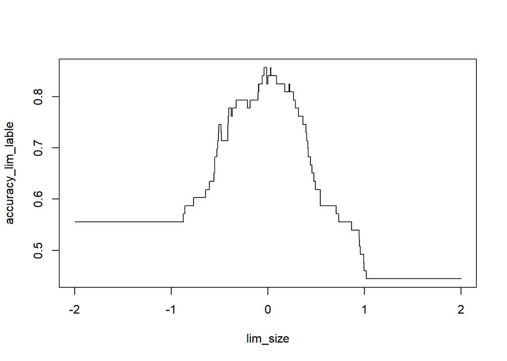

```r
### plotting accuracy by lim
plot(lim_size,accuracy_lim_lable,type = "l")
```

# Question 3

## 3.a

### 3.a.i

```r
Tehran_home_prices = read.csv("Question_3_Data.csv", encoding = "UTF-8")

colnames(Tehran_home_prices) <- c("Region", "99.sp", c("98.w","98.f","98.su","98.sp"), c("97.w","97.f","97.su","97.sp"), c("96.w","96.f","96.su","96.sp"), c("95.w","95.f","95.su","95.sp"), c("94.w","94.f","94.su","94.sp"), c("93.w","93.f","93.su","93.sp"),c("92.w","92.f","92.su","92.sp"),c("91.w","91.f","91.su","91.sp"),c("90.w","90.f","90.su","90.sp"),c("89.w","89.f","89.su","89.sp"),c("88.w","88.f","88.su","88.sp")) ### set up new names for headers of our dataset.


### changing bad data to NA
t_price = Tehran_home_prices[3:25,2:46]

defaultW <- getOption("warn")
options(warn = -1)

for (i in 1:45) {
  t_price[,i] = as.numeric(t_price[,i])
}

options(warn = defaultW) ### this is for not printing warning comment

t_price[t_price == 0] <- NA  ### replace zero values with NA

NA_num_of_data = sapply(t_price, function(x) sum(is.na(x)))

NA_num_of_data
```

```
## 99.sp  98.w  98.f 98.su 98.sp  97.w  97.f 97.su 97.sp  96.w  96.f 96.su 96.sp
##     0     0     0     2     0     0     0     1     0     0     0     1     2
##  95.w  95.f 95.su 95.sp  94.w  94.f 94.su 94.sp  93.w  93.f 93.su 93.sp  92.w
##     0     0     0     0     0     0     0     0     0     0     0     0     0
##  92.f 92.su 92.sp  91.w  91.f 91.su 91.sp  90.w  90.f 90.su 90.sp  89.w  89.f
##     0     0     0     0     1     0     0     0     1     1     4     4     6
## 89.su 89.sp  88.w  88.f 88.su 88.sp
##    13     9    19    18    19     8
```

### 3.a.ii

In this part, I remove columns that have more than 7 NA data and for other columns, I rather not to replace NA data with something else, because replacing NA data with anything makes an error that can cause wrong conclusions. so I don’t replace NA data with anything else and imagine that we didn’t have these data at first, so in our regression we would not have error too much and cause to be more accurate.(I talk about this method to TA and he was OK with that.)

```r
### removing columns with NA data more than 7

for(i in 1:7){
  for (i in 1:45) {
    if(NA_num_of_data[i] > 7){
       t_price = t_price[-i]
    }
  }
}
```

### 3.a.iii

```r
### saving new data set as an excel file

Tehran_new_home_price = Tehran_home_prices[1:40]

Tehran_new_home_price[3:25,2:40] = t_price

### write_xlsx(Tehran_new_home_price, "C:\\Users\\RAYAN SERVICE\\Dropbox\\My PC (GetCH)\\Desktop\\Stat_Project\\Tehran_new_home_price.xlsx") #### I commented this part because I already put the written file in the file of my project and if I didn't make that line as a comment it could cause an error in your computer :)) !! But as I said I put the excel file in my project file.
```

## 3.b

### 3.b.i

At first we calculate K. My student number is 98104852 and rest of my student number in divided by 22 is 10. so K+1 is equal to 11. So I have to do regression for 11th region home price of Tehran. Actually because in our time line we both have month and year, I set this relation that year has coefficient of 4 and fall is 0, winter is 1, spring is 2 and summer is 3 and the relation is (4*year+season) and our beginning is fall of 88. So fall of 88 is 1 and for example winter of 90 is equal to 10. So with this relation for time we do regression for region 11.

```r
### our time line is from 1 to 39
time_line = c(0:38)

region_11_price = c(1:39)

for (i in 1:39) {
  region_11_price[i] = t_price[12,][1,40-i]
}

price_regression = lm(region_11_price ~ time_line)

summary(price_regression)
```

```
##
## Call:
## lm(formula = region_11_price ~ time_line)
##
## Residuals:
##    Min     1Q Median     3Q    Max
## -26965 -16030   3417   9151  72656
##
## Coefficients:
##             Estimate Std. Error t value Pr(>|t|)
## (Intercept)  -1437.5     6597.9  -0.218    0.829
## time_line     2153.4      298.8   7.207  1.5e-08 ***
## ---
## Signif. codes:  0 '***' 0.001 '**' 0.01 '*' 0.05 '.' 0.1 ' ' 1
##
## Residual standard error: 21000 on 37 degrees of freedom
## Multiple R-squared:  0.584,  Adjusted R-squared:  0.5728
## F-statistic: 51.95 on 1 and 37 DF,  p-value: 1.503e-08
```

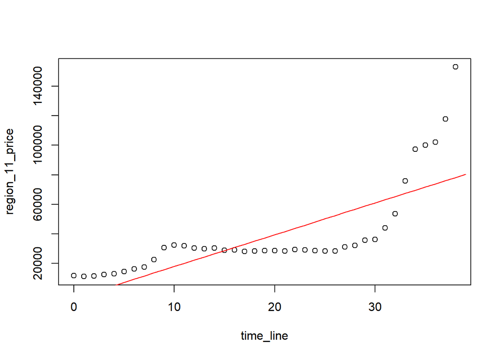

```r
plot(time_line,region_11_price)

lines(coef(price_regression)[1] + coef(price_regression)[2]*time_line, col = "red")
```

```r
cat("Result regression line is price_of_region_11 =" ,coef(price_regression)[1],"+", coef(price_regression)[2],"* time_line")
```

```
## Result regression line is price_of_region_11 = -1437.532 + 2153.418 * time_line
```

### 3.b.ii

In this part at first I make a new data frame that contains time, region and price and on that data frame I put price of an specific time

```r
#####At first we create a new data frame for our regression by time and region for price

time_regress = rep(c(0:38),each=22)

region_regress = rep(c(1:22),times = 39)

price_regress = c(1:858)

for (i in 1:39) {
  for (j in 2:23) {
    price_regress[(i-1)*22+j-1] = t_price[j,40-i]

  }
}

reg_df = data.frame(region_regress,time_regress,price_regress)

total_price_regression = lm(reg_df$price_regress ~ reg_df$time_regress + reg_df$region_regress)

summary(total_price_regression)
```

```
##
## Call:
## lm(formula = reg_df$price_regress ~ reg_df$time_regress + reg_df$region_regress)
##
## Residuals:
##    Min     1Q Median     3Q    Max
## -74301 -28815  -9057  16957 383533
##
## Coefficients:
##                       Estimate Std. Error t value Pr(>|t|)
## (Intercept)            43275.1     4710.3   9.187   <2e-16 ***
## reg_df$time_regress     3589.9      158.9  22.599   <2e-16 ***
## reg_df$region_regress  -4661.6      277.3 -16.813   <2e-16 ***
## ---
## Signif. codes:  0 '***' 0.001 '**' 0.01 '*' 0.05 '.' 0.1 ' ' 1
##
## Residual standard error: 50870 on 832 degrees of freedom
##   (23 observations deleted due to missingness)
## Multiple R-squared:  0.4851, Adjusted R-squared:  0.4838
## F-statistic: 391.9 on 2 and 832 DF,  p-value: < 2.2e-16
```

```r
cat("Result regression plate is price =" ,coef(total_price_regression)[1],"+", coef(total_price_regression)[2],"* time", "+", coef(total_price_regression)[3], "* region")
```

```
## Result regression plate is price = 43275.06 + 3589.927 * time + -4661.563 * region
```

### 3.b.iii

In this part we have to define dummy (indicator) variable for each region and then do the regression for them.

```r
### creating dummy variables data frame for each region (we don't define any dummy variable for region 11(K+1) and for region 11, all dummy variables of other regions are zero.)
dummy_variables_region = data.frame(dm_region_1 = ifelse(reg_df$region_regress == 1,1,0),
dm_region_2 = ifelse(reg_df$region_regress == 2,1,0),
dm_region_3 = ifelse(reg_df$region_regress == 3,1,0),
dm_region_4 = ifelse(reg_df$region_regress == 4,1,0),
dm_region_5 = ifelse(reg_df$region_regress == 5,1,0),
dm_region_6 = ifelse(reg_df$region_regress == 6,1,0),
dm_region_7 = ifelse(reg_df$region_regress == 7,1,0),
dm_region_8 = ifelse(reg_df$region_regress == 8,1,0),
dm_region_9 = ifelse(reg_df$region_regress == 9,1,0),
dm_region_10 = ifelse(reg_df$region_regress == 10,1,0),
dm_region_12 = ifelse(reg_df$region_regress == 12,1,0),
dm_region_13 = ifelse(reg_df$region_regress == 13,1,0),
dm_region_14 = ifelse(reg_df$region_regress == 14,1,0),
dm_region_15 = ifelse(reg_df$region_regress == 15,1,0),
dm_region_16 = ifelse(reg_df$region_regress == 16,1,0),
dm_region_17 = ifelse(reg_df$region_regress == 17,1,0),
dm_region_18 = ifelse(reg_df$region_regress == 18,1,0),
dm_region_19 = ifelse(reg_df$region_regress == 19,1,0),
dm_region_20 = ifelse(reg_df$region_regress == 20,1,0),
dm_region_21 = ifelse(reg_df$region_regress == 21,1,0),
dm_region_22 = ifelse(reg_df$region_regress == 22,1,0))

reg_df_dummy = data.frame(reg_df,dummy_variables_region)

regression_dummy_var = lm(reg_df_dummy$price_regress ~
                          +reg_df_dummy$time_regress
                          +reg_df_dummy$dm_region_1
                          +reg_df_dummy$dm_region_2
                          +reg_df_dummy$dm_region_3
                          +reg_df_dummy$dm_region_4
                          +reg_df_dummy$dm_region_5
                          +reg_df_dummy$dm_region_6
                          +reg_df_dummy$dm_region_7
                          +reg_df_dummy$dm_region_8
                          +reg_df_dummy$dm_region_9
                          +reg_df_dummy$dm_region_10
                          +reg_df_dummy$dm_region_12
                          +reg_df_dummy$dm_region_13
                          +reg_df_dummy$dm_region_14
                          +reg_df_dummy$dm_region_15
                          +reg_df_dummy$dm_region_16
                          +reg_df_dummy$dm_region_17
                          +reg_df_dummy$dm_region_18
                          +reg_df_dummy$dm_region_19
                          +reg_df_dummy$dm_region_20
                          +reg_df_dummy$dm_region_21
                          +reg_df_dummy$dm_region_22)


summary(regression_dummy_var)
```

```
##
## Call:
## lm(formula = reg_df_dummy$price_regress ~ +reg_df_dummy$time_regress +
##     reg_df_dummy$dm_region_1 + reg_df_dummy$dm_region_2 + reg_df_dummy$dm_region_3 +
##     reg_df_dummy$dm_region_4 + reg_df_dummy$dm_region_5 + reg_df_dummy$dm_region_6 +
##     reg_df_dummy$dm_region_7 + reg_df_dummy$dm_region_8 + reg_df_dummy$dm_region_9 +
##     reg_df_dummy$dm_region_10 + reg_df_dummy$dm_region_12 + reg_df_dummy$dm_region_13 +
##     reg_df_dummy$dm_region_14 + reg_df_dummy$dm_region_15 + reg_df_dummy$dm_region_16 +
##     reg_df_dummy$dm_region_17 + reg_df_dummy$dm_region_18 + reg_df_dummy$dm_region_19 +
##     reg_df_dummy$dm_region_20 + reg_df_dummy$dm_region_21 + reg_df_dummy$dm_region_22)
##
## Residuals:
##    Min     1Q Median     3Q    Max
## -68090 -31618  -7947  20086 347287
##
## Coefficients:
##                           Estimate Std. Error t value Pr(>|t|)
## (Intercept)               -29190.0     8175.1  -3.571 0.000377 ***
## reg_df_dummy$time_regress   3614.1      149.6  24.151  < 2e-16 ***
## reg_df_dummy$dm_region_1   86093.4    10839.6   7.943 6.59e-15 ***
## reg_df_dummy$dm_region_2   78443.3    10839.6   7.237 1.07e-12 ***
## reg_df_dummy$dm_region_3   93809.6    10839.6   8.654  < 2e-16 ***
## reg_df_dummy$dm_region_4   44101.5    10839.6   4.069 5.19e-05 ***
## reg_df_dummy$dm_region_5   32635.4    10839.6   3.011 0.002687 **
## reg_df_dummy$dm_region_6   67560.9    10910.9   6.192 9.42e-10 ***
## reg_df_dummy$dm_region_7   38361.6    10839.6   3.539 0.000424 ***
## reg_df_dummy$dm_region_8   27906.5    10839.6   2.575 0.010214 *
## reg_df_dummy$dm_region_9   -3368.9    11146.5  -0.302 0.762548
## reg_df_dummy$dm_region_10   1099.6    10839.6   0.101 0.919221
## reg_df_dummy$dm_region_12  -5015.3    10839.6  -0.463 0.643713
## reg_df_dummy$dm_region_13  18230.8    10839.6   1.682 0.092977 .
## reg_df_dummy$dm_region_14   8482.3    10910.7   0.777 0.437132
## reg_df_dummy$dm_region_15  -9591.9    10910.7  -0.879 0.379595
## reg_df_dummy$dm_region_16  -8967.9    11065.3  -0.810 0.417922
## reg_df_dummy$dm_region_17 -18571.8    11148.9  -1.666 0.096138 .
## reg_df_dummy$dm_region_18 -16773.2    10910.9  -1.537 0.124612
## reg_df_dummy$dm_region_19 -15934.9    11231.8  -1.419 0.156363
## reg_df_dummy$dm_region_20 -19945.3    10839.6  -1.840 0.066125 .
## reg_df_dummy$dm_region_21  -4784.0    11063.1  -0.432 0.665544
## reg_df_dummy$dm_region_22   7694.0    10839.6   0.710 0.478025
## ---
## Signif. codes:  0 '***' 0.001 '**' 0.01 '*' 0.05 '.' 0.1 ' ' 1
##
## Residual standard error: 47870 on 812 degrees of freedom
##   (23 observations deleted due to missingness)
## Multiple R-squared:  0.5551, Adjusted R-squared:  0.5431
## F-statistic: 46.05 on 22 and 812 DF,  p-value: < 2.2e-16
```

## 3.c

### 3.c.i

At first we calculate K. My student number is 98104852 and rest of my student number in divided by 22 is 10. so K+1 is equal to 11. As we assume that winter of 90 is zero so summer of 93 is 10th season and fall of 93 is K+1th season. In this part null hypothesis is that the price of home doesn’t change in passing a season and we have to accept or reject this hypothesis in this part. so h0 is that : mean_yi - mean_xi = 0.

```r
x_i = t_price$`93.su`[2:23]
y_i = t_price$`93.f`[2:23]

mean_xi = mean(x_i)

mean_yi = mean(y_i)

mean_diff = mean_xi - mean_yi
cat("mean diffrence of mean of x_i and mean of y_i is equal to",mean_diff)
```

```
## mean diffrence of mean of x_i and mean of y_i is equal to -1653.773
```

```r
sp2 = ((length(x_i)* sd(x_i)^2) + (length(y_i)* sd(y_i)^2))/(length(x_i)+length(y_i)-2)
cat("Variance of the mean diffrence is equal to", sp2)
```

```
## Variance of the mean diffrence is equal to 483288867
```

```r
stat = (mean_xi - mean_yi)/ sqrt(sp2/length(x_i) + sp2/length(y_i))
cat("t value of our test is euqal to", stat)
```

```
## t value of our test is euqal to -0.249499
```

```r
test_1 = t.test(x_i,y_i,paired = FALSE)
test_1
```

```
##
##  Welch Two Sample t-test
##
## data:  x_i and y_i
## t = -0.25537, df = 41.728, p-value = 0.7997
## alternative hypothesis: true difference in means is not equal to 0
## 95 percent confidence interval:
##  -14725.35  11417.80
## sample estimates:
## mean of x mean of y
##  38570.55  40224.32
```

```r
cat("p-value of this t.test is equal to:",test_1$p.value)
```

```
## p-value of this t.test is equal to: 0.7996916
```

### 3.c.ii

```r
z_i = x_i - y_i

mean_zi = mean(z_i)
cat("mean of z_i is equal to",mean_zi)
```

```
## mean of z_i is equal to -1653.773
```

```r
var_zi = var(z_i)
cat("variance of z_i is equal to",var_zi)
```

```
## variance of z_i is equal to 3306524
```

```r
stat_2 = mean_zi/sqrt(var_zi/length(z_i))
cat("t-value of our test is equal to",stat_2)
```

```
## t-value of our test is equal to -4.265808
```

```r
test_2 = t.test(x_i,y_i, paired = TRUE)
test_2
```

```
##
##  Paired t-test
##
## data:  x_i and y_i
## t = -4.2658, df = 21, p-value = 0.0003441
## alternative hypothesis: true difference in means is not equal to 0
## 95 percent confidence interval:
##  -2459.999  -847.546
## sample estimates:
## mean of the differences
##               -1653.773
```

```r
cat("p-value of our test is equal to:",test_2$p.value)
```

```
## p-value of our test is equal to: 0.0003441109
```